# Deep Learning for Tabular Data

## Multiple Linear Regression

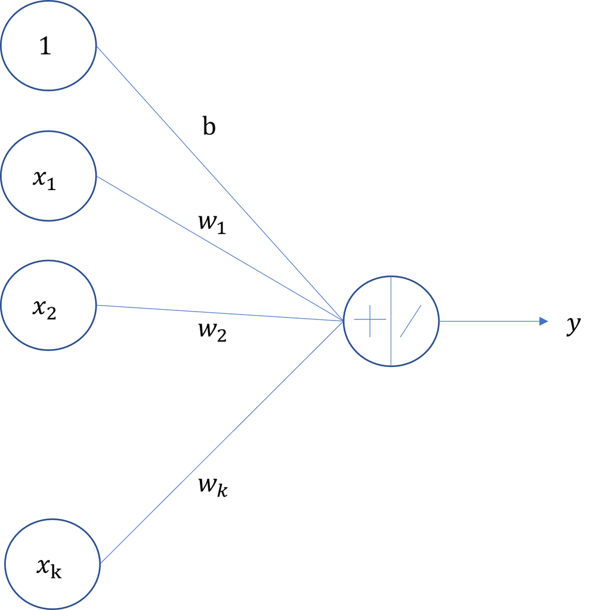

Linear Regression as Deep Learning Architecture

$$\hat{y}^i = w_1x_1^i + w_2x_2^i + ... + w_kx_k^i + b$$

$$\hat{y} = \mathbf{xw} + b$$

$$\mathbf{\hat{y}} = \mathbf{Xw} + b$$

## Pytorch Implementation

```python
import torch
from torch.nn import Linear


torch.manual_seed(1)
mdl = Linear(in_features=2,out_features=1)
list(mdl.parameters())
X = torch.rand(size=(3,2))
print(mdl(X))
```

```
tensor([[ 0.1215],
        [ 0.0304],
        [-0.0400]], grad_fn=<AddmmBackward0>)
```

### Custom Module

In PyTorch it is customary to construct custom modules

```python
import torch.nn as nn

class LR(nn.Module):
    def __init__(self, input_size, output_size):
        super(LR, self).__init__()
        self.linear = nn.Linear(input_size, output_size)

    def forward(self, x):
        return self.linear(x)
```

## Cost Function

$$L(\mathbf{w},b) = \frac{1}{n}\sum_{i = 1}^n \left({y^i - \hat{y}^i}\right)^2$$
$$L(\mathbf{w},b) = \frac{1}{n}\sum_{i = 1}^n \left({y^i - \mathbf{x^iw}-b}\right)^2$$

## Initialize Data

```python
from torch.utils.data import Dataset, DataLoader

class Data(Dataset):
    def __init__(self):
        self.x = torch.zeros(20,2)
        self.x[:,0] = torch.arange(-1,1,0.1)
        self.x[:,1] = torch.arange(-1,1,0.1)
        self.w = torch.tensor([[1.0],[1.0]])
        self.b = 1
        self.f = torch.mm(self.x, self.w) + self.b
        self.y = self.f + 0.1*torch.randn(self.f.shape)
        self.len = self.x.shape[0]

    def __getitem__(self, index):
        return self.x[index], self.y[index]

    def __len__(self):
        return self.len
```

This code defines the `Data` class, which inherits from the `Dataset` class in PyTorch. The constructor (`__init__`) initializes various attributes of the dataset.

- `self.x[:, 0] = torch.arange(-1, 1, 0.1)` and `self.x[:, 1] = torch.arange(-1, 1, 0.1)`: It initializes a 2-dimensional tensor `self.x` with values ranging from -1 to 1 with a step of 0.1 in both dimensions.
- `self.w = torch.tensor([[1.0], [1.0]])`: It initializes a weight tensor `self.w` with values `[1.0]` in both dimensions.
- `self.b = 1`: It initializes a bias term `self.b` with a value of 1.
- `self.f = torch.mm(self.x, self.w) + self.b`: It calculates the linear function `self.f` using matrix multiplication (`torch.mm`) between `self.x` and `self.w`, and then adding the bias term `self.b`.
- `self.y = self.f + 0.1 * torch.randn(self.f.shape)`: It adds random noise to the calculated function `self.f` to create the target values `self.y`. This simulates a scenario where real-world data may have some level of noise.
- `self.len = self.x.shape[0]`: It sets the length of the dataset (`self.len`) based on the number of rows in `self.x`.

```python
def __getitem__(self, index):
    return self.x[index], self.y[index]
```

This method, `__getitem__`, is required by the `Dataset` class. It is used to retrieve a specific sample from the dataset given an index. In this case, it returns a tuple containing input (`self.x[index]`) and target (`self.y[index]`) values for the given index.

```python
def __len__(self):
    return self.len
```

This method, `__len__`, is also required by the `Dataset` class. It returns the length of the dataset, which was set during initialization as `self.len`.

## Initializing Model Parameters

```python
from torch import optim
data = Data()
criterion = nn.MSELoss()
trainloader = DataLoader(dataset=data, batch_size=2)
mdl = LR(input_size=2,output_size=1)
optimizer = optim.SGD(mdl.parameters(), lr = 0.1)
```

- An instance of the `Data` class is created (`data`).
- The mean squared error loss (`criterion`) is instantiated using `nn.MSELoss()`.
- A `DataLoader` (`trainloader`) is created to handle batches of size 2 during training.
- An instance of the linear regression model (`mdl`) is created using the `LR` class with an input size of 2 and an output size of 1.
- An `SGD optimizer` that will update the parameters of the `mdl` during training, using a learning rate of 0.1 is created. This optimizer will be used in the training loop to update the model parameters based on the computed gradients during backpropagation.

## Training Model

```python
cost =  []
for epoch in range(100):
    for x,y in trainloader:
        yhat = mdl(x)
        loss = criterion(yhat,y)
        cost.append(loss.data)
        optimizer.zero_grad()
        loss.backward()
        optimizer.step()
```

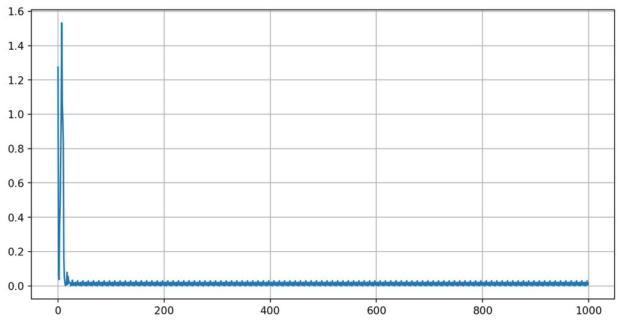

```python
import matplotlib.pyplot as plt
plt.plot(cost)
plt.grid()
```

- `for x, y in trainloader:`: This inner loop iterates over batches of data from the `trainloader`. Each iteration provides a batch of input (`x`) and target (`y`) tensors.
- `yhat = mdl(x)`: This line computes the model’s predictions (`yhat`) given the input (`x`) using the forward pass of the model.
- `loss = criterion(yhat, y)`: This calculates the loss using the mean squared error (MSE) criterion. The difference between the predicted values (`yhat`) and the actual target values (`y`) is computed and squared, and the mean of these squared differences is taken.
- `cost.append(loss)`: The calculated loss for the current batch is appended to the `cost` list. This allows you to track the change in loss during training.
- `optimizer.zero_grad()`: This resets the gradients of the model parameters to zero. Gradients accumulate by default in PyTorch, so it’s necessary to clear them before computing new gradients.
- `loss.backward()`: This computes the gradients of the model parameters with respect to the loss using backpropagation.
- `optimizer.step()`: This updates the model parameters using the optimizer. The optimizer uses the computed gradients to perform a step in the direction that minimizes the loss.

## Linear Regression with Multiple Outputs

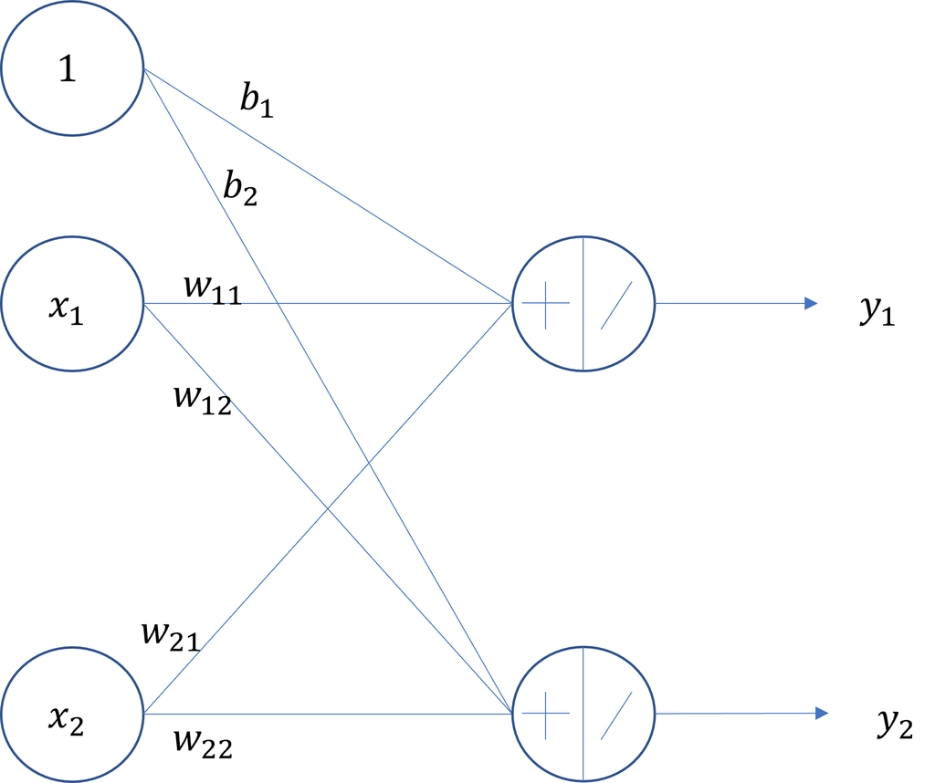

Linear Regression with Multiple Outputs

$$\mathbf{y}_{nxk} = \mathbf{X}_{nxm}\mathbf{W}_{mxk} + \mathbf{b}_{1xk}$$

```python
torch.manual_seed(1)
mdl = Linear(in_features=2,out_features=2)
list(mdl.parameters())
X = torch.rand(size=(3,2))
print(mdl(X))
```

```
tensor([[-0.7564,  0.6200],
        [-0.5951,  0.4916],
        [-0.5967,  0.5106]], grad_fn=<AddmmBackward0>)
```

$$L(\mathbf{w,b}) = \frac{1}{n}\sum_{i = 1}^n \left({||y^i - \mathbf{x^iw}+b}||\right)^2$$

## Logistic Regression

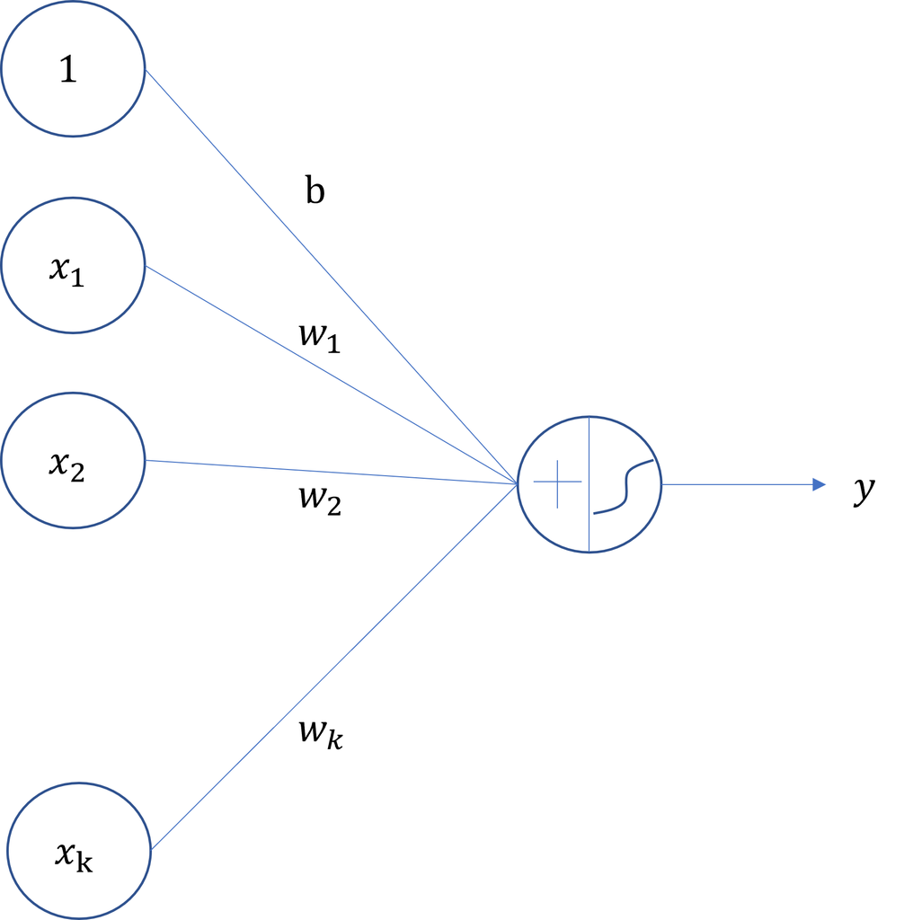

Logistic Regression

$$\hat{z}^i = w_1x_1^i + w_2x_2^i + ... + w_kx_k^i + b$$

$$y^i = \begin{cases}
1 & \text{if } a^i > 0.5 \\
0 & \text{if } a^i \leq 0.5
\end{cases}$$

## Logistic Regression in PyTorch

```python
class LogisticRegression(nn.Module):
    def __init__(self, input_size):
        super(LogisticRegression, self).__init__()
        self.linear = nn.Linear(input_size, 1)

    def forward(self, x):
        z = self.linear(x)
        a = torch.sigmoid(z)
        return a
```

- `self.linear = nn.Linear(input_size, 1)`: This line creates a linear layer (`nn.Linear`) as a member of the class. It represents the linear transformation (weight * input + bias) with `input_size` input features and 1 output feature, which is typical for logistic regression.
- `z = self.linear(x)`: This line applies the linear transformation to the input `x` using the weights and biases defined in the `self.linear` layer. The result is stored in `z`.
- `a = torch.sigmoid(z)`: The logistic sigmoid function (`torch.sigmoid`) is applied to the linear output `z`. This operation squashes the values between 0 and 1, which is common in logistic regression, providing the probability of belonging to the positive class.

## Binary Cross-entropy

Binary Cross-Entropy, often referred to as log loss, is a loss function commonly used in binary classification problems. It measures the difference between the true binary labels and the predicted probabilities for a binary classification task. The formula for binary cross-entropy for a single observation is:

$$L(y, \hat{y}) = - (y \cdot \log(\hat{y}) + (1 - y) \cdot \log(1 - \hat{y}))$$

- $L(y, \hat{y})$: Binary cross-entropy loss for a single observation.
- $y$: The true label (ground truth), which is either 0 or 1.
- $\hat{y}$: The predicted probability that the instance belongs to class 1.

## Logistic Regression : PyTorch

```python
data = Data()
criterion = nn.BCELoss()
trainloader = DataLoader(dataset=data, batch_size=2)
mdl = LR(input_size=2,output_size=1)
optimizer = optim.SGD(mdl.parameters(), lr = 0.1)
```